# Hockey sticks, rank dif, and clustering

```r
#source("~/Script repository/R scripting/My_Useful_Fns.R")#02/01/2022 commit at my github https://github.com/McK-Ford/Script-repository/blob/main/R%20scripting/My_Useful_Fns.R
library(tidyverse)
library(data.table)
pI_tab_wide <- read.delim("~/Script repository/R scripting/Interactive/Project Cell Lines/Peppro_analysis/peppro_pIs_w_rank.tsv")
```

```r
top_10perc <- pI_tab_wide |>
  filter(!grepl('chrY|chrX', chrom)) |>
  filter(pI_SUM159 >= quantile(pI_SUM159, 0.9, na.rm = TRUE) |
         pI_T47D >= quantile(pI_T47D, 0.9, na.rm = TRUE) |
         pI_MB231 >= quantile(pI_MB231, 0.9, na.rm = TRUE) |
         pI_MCF7 >= quantile(pI_MCF7, 0.9, na.rm = TRUE) |
         pI_MCF10A >= quantile(pI_MCF10A, 0.9, na.rm = TRUE))
```

That’s 2844.

```r
top_10perc_log10 <- cbind(
  top_10perc[,1:5], log10(as.matrix(top_10perc[,6:10])), top_10perc[,11:15]
  )
```

Will have basically nothing if I remove NA

```r
top_10perc_log10 <- top_10perc_log10 |>
  rowwise() |>
  mutate(stdev = sd(c(pI_MCF7, pI_SUM159, pI_MCF10A, pI_T47D, pI_MB231),
                    na.rm=TRUE),
         meanpi = mean(c(pI_MCF7, pI_SUM159, pI_MCF10A, pI_T47D, pI_MB231),
                       na.rm = TRUE)) |>
  ungroup()
```

(Need ungroup, otherwise is rowwise df and causes problems later)

```r
pI_norm <- top_10perc_log10 |>
  rowwise() |>
  mutate(MB231norm = (pI_MB231 - meanpi) / stdev,
        MCF10Anorm = (pI_MCF10A - meanpi) / stdev,
        MCF7norm = (pI_MCF7 - meanpi) / stdev,
         SUM159norm = (pI_SUM159 - meanpi) / stdev,
         T47Dnorm = (pI_T47D - meanpi) / stdev) |>
  ungroup()
```

Normalized matrix:

```r
simple_mat <- as.matrix(pI_norm[,18:22])
rownames(simple_mat) <- pI_norm[[4]]
colnames(simple_mat) <- c("MB231", "MCF10A", "MCF7", "SUM159", "T47D")
```

```r
simple_mat_nn <- as.matrix(pI_norm[,6:10])
rownames(simple_mat) <- pI_norm[[4]]
colnames(simple_mat) <- c("MB231", "MCF10A", "MCF7", "SUM159", "T47D")
```

Oh I see what the problem is. Anything with only one gene with signal can’t calculate stdev/mean, so that column is turned into NA, making every normalized column for that gene a NA.

And you can’t calc a distance matrix with rows that have only one real value.

So how do I filter to ‘at least 2 non-NA values?’

https://groups.google.com/g/r-help-archive/c/biHWpmFeWoM?pli=1 “The error appears to be a result of the missing values yielded by the dist() function on your matrix. See https://stat.ethz.ch/pipermail/r-help/2009-July/204443.html.”

True is worth 1 and False is 0…

```r
pI_norm <- top_10perc_log10 |>
  rowwise() |>
  mutate(MB231norm = (pI_MB231 - meanpi) / stdev,
        MCF10Anorm = (pI_MCF10A - meanpi) / stdev,
        MCF7norm = (pI_MCF7 - meanpi) / stdev,
         SUM159norm = (pI_SUM159 - meanpi) / stdev,
         T47Dnorm = (pI_T47D - meanpi) / stdev) |>
  ungroup() |>
  filter(
    2 <= (as.numeric(!is.na(pI_MB231)) +
      as.numeric(!is.na(pI_MCF10A)) +
      as.numeric(!is.na(pI_MCF7)) +
      as.numeric(!is.na(pI_SUM159)) +
      as.numeric(!is.na(pI_T47D)))
    ) |>
  ungroup()
```

Apparently if I don’t as.numeric each one it will only take the numeric value of the final comparison because it’s stupid like that, instead of everything added together. You can calc TRUE + TRUE but for some reason it doesn’t work here. 1698 genes.

Normalized matrix:

```r
simple_mat <- as.matrix(pI_norm[,18:22])
rownames(simple_mat) <- pI_norm[[4]]
colnames(simple_mat) <- c("MB231", "MCF10A", "MCF7", "SUM159", "T47D")
```

```r
hm1 <- heatmap(simple_mat, scale="none", cexCol = 0.8, labRow = "", main = "pI clustering, row norm, (n=2844)", na.rm = TRUE, na.color="black")
```

```
Error in hclustfun(distfun(x)) :
  NA/NaN/Inf in foreign function call (arg 10)
```

Ugh, I really did think that would fix it…I’m telling it explicitly to remove NAs.

```r
test = as.matrix(dist(simple_mat))
test2 = as.matrix(dist(t(simple_mat)))
foo = unique(is.na(test))
```

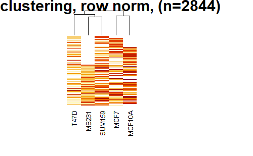

```r
hm1 <- heatmap(simple_mat, scale="none", cexCol = 0.8, labRow = "", main = "pI clustering, row norm, (n=2844)", na.rm = TRUE, Rowv = NA)
```

Yep, that’s exactly the problem. The matrix is too sparse, so if I don’t interpolate 0s into it or some other placeholder, the rows/genes cannot be clustered.

What if I filter to ‘at least 3 non-NA values?’ Is that enough to calculate a distance matrix?

```r
pI_norm <- top_10perc_log10 |>
  rowwise() |>
  mutate(MB231norm = (pI_MB231 - meanpi) / stdev,
        MCF10Anorm = (pI_MCF10A - meanpi) / stdev,
        MCF7norm = (pI_MCF7 - meanpi) / stdev,
         SUM159norm = (pI_SUM159 - meanpi) / stdev,
         T47Dnorm = (pI_T47D - meanpi) / stdev) |>
  ungroup() |>
  filter(
    3 <= (as.numeric(!is.na(pI_MB231)) +
      as.numeric(!is.na(pI_MCF10A)) +
      as.numeric(!is.na(pI_MCF7)) +
      as.numeric(!is.na(pI_SUM159)) +
      as.numeric(!is.na(pI_T47D)))
    ) |>
  ungroup()
```

Normalized matrix:

```r
simple_mat <- as.matrix(pI_norm[,18:22])
rownames(simple_mat) <- pI_norm[[4]]
colnames(simple_mat) <- c("MB231", "MCF10A", "MCF7", "SUM159", "T47D")
```

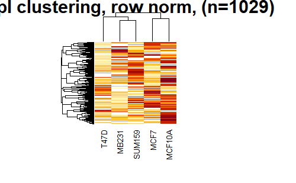

```r
hm1 <- heatmap(simple_mat, scale="none", cexCol = 0.8, labRow = "", main = "pI clustering, row norm, (n=1029)", na.rm = TRUE)
```